You can do this on your own data, or on included data here.

## Continuous data

```r
library(geiger)
library(ape)
tree.primates <- read.tree(text="((((Homo:0.21,Pongo:0.21):0.28,Macaca:0.49):0.13,Ateles:0.62):0.38,Galago:1.00);") #using examples from ape ?pic
X <- c(4.09434, 3.61092, 2.37024, 2.02815, -1.46968)
Y <- c(4.74493, 3.33220, 3.36730, 2.89037, 2.30259)
names(X) <- names(Y) <- c("Homo", "Pongo", "Macaca", "Ateles", "Galago")
pic.X <- ape::pic(X, tree.primates)
pic.Y <- ape::pic(Y, tree.primates)
```

Now, positivitize the contrasts and do a regression through the origin.

## Discrete data

```r
require("corHMM")
?corHMM
```

```
## starting httpd help server ...
```

```
##  done
```

```r
data(primates)
ls()
```

```
## [1] "pic.X"         "pic.Y"         "primates"      "tree.primates"
## [5] "X"             "Y"
```

```r
print(primates)
```

```
## $tree
##
## Phylogenetic tree with 60 tips and 58 internal nodes.
##
## Tip labels:
##  Homo_sapiens, Pan_paniscus, Pan_troglodytes, Gorilla_gorilla, Pongo_pygmaeus, Pongo_pygmaeus_abelii, ...
##
## Rooted; includes branch lengths.
##
## $trait
##                    Genus_sp T1 T2
## 1      Cercocebus_torquatus  1  1
## 2    Cercopithecus_aethiops  0  1
## 3        Cercopithecus_mona  0  0
## 4   Cercopithecus_nictitans  0  0
```

[output cut: 56 more lines]

```r
require(phytools)
```

Just to make this a better dataset for our exercise, I’m going to change some of the states (I want to have all four trait combinations present). For actual analyses, of course, DO NOT INVENT YOUR DATA.

First, a review of discrete state models:

```
## make.simmap is sampling character histories conditioned on the transition matrix
##
## Q =
##             0           1
## 0 -0.01076402  0.01076402
## 1  0.01076402 -0.01076402
## (estimated using likelihood);
## and (mean) root node prior probabilities
## pi =
##   0   1
## 0.5 0.5
```

```
## Done.
```

```
## no colors provided. using the following legend:
##       0       1
## "black"   "red"
```

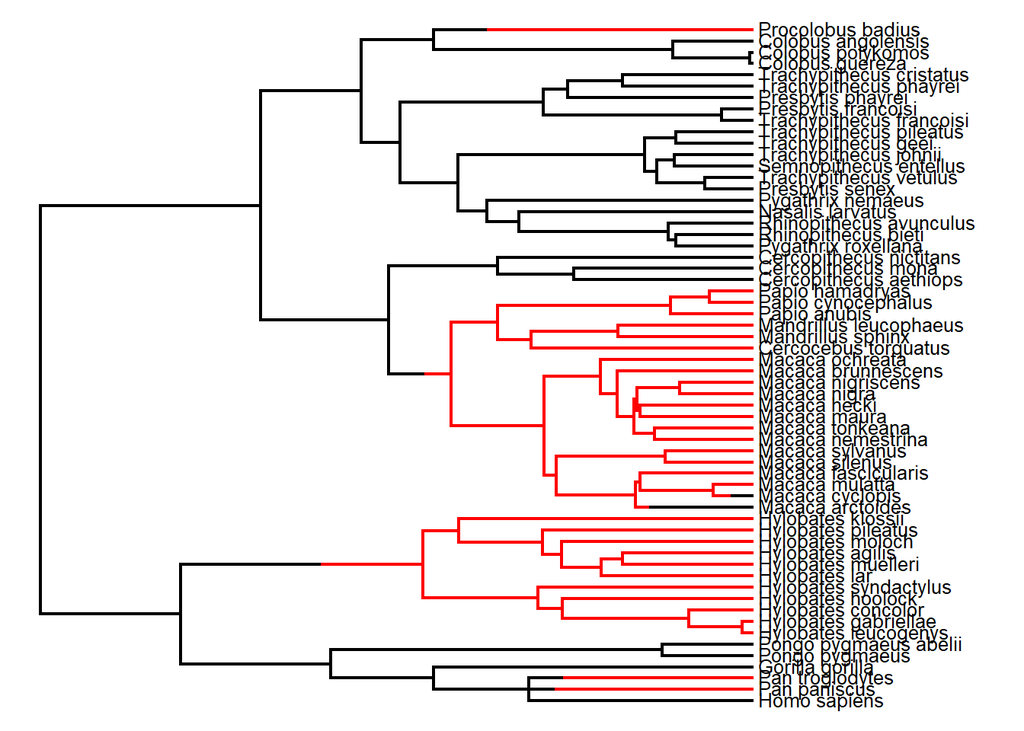

```r
primates$trait[which(grepl("Hylobates",primates$trait[,1])),2]<-1

trait1<-primates$trait[,2]
names(trait1)<-primates$trait[,1]
plotSimmap(make.simmap(primates$tree, trait1), pts=FALSE, fsize=0.8)
```

```r
rate.mat.er<-rate.mat.maker(rate.cat=1, hrm=FALSE, ntraits=1, nstates=2, model="ER")
print(rate.mat.er)
```

```
##    1  2
## 1 NA  1
## 2  1 NA
```

What does this matrix mean?

```r
pp.er<-corHMM(primates$tree,primates$trait[,c(1,2)],rate.cat=1,rate.mat=rate.mat.er,node.states="marginal")
```

```
## State distribution in data:
## States:  0   1
## Counts:  28  32
## Beginning thorough optimization search -- performing 10 random restarts
## Finished. Inferring ancestral states using marginal reconstruction.
## Finished. Performing diagnostic tests.
```

```r
print(pp.er)
```

```
##
## Fit
##       -lnL     AIC     AICc Rate.cat ntax
##  -23.41535 48.8307 48.89967        1   60
##
## Rates
##            (0)        (1)
## (0)         NA 0.01076354
## (1) 0.01076354         NA
##
## Arrived at a reliable solution
```

What do these results mean?

```r
rate.mat.ard<-rate.mat.maker(rate.cat=1, hrm=FALSE, ntraits=1, nstates=2, model="ARD")
print(rate.mat.ard)
```

```
##    1  2
## 1 NA  2
## 2  1 NA
```

And these?

```r
pp.ard<-corHMM(primates$tree,primates$trait[,c(1,2)],rate.cat=1,rate.mat=rate.mat.ard,node.states="marginal")
```

```
## State distribution in data:
## States:  0   1
## Counts:  28  32
## Beginning thorough optimization search -- performing 10 random restarts
## Finished. Inferring ancestral states using marginal reconstruction.
## Finished. Performing diagnostic tests.
```

```r
print(pp.ard)
```

```
##
## Fit
##      -lnL      AIC     AICc Rate.cat ntax
##  -23.4128 50.82561 51.03614        1   60
##
## Rates
##            (0)        (1)
## (0)         NA 0.01032985
## (1) 0.01127975         NA
##
## Arrived at a reliable solution
```

which model is better?

Now let’s look at multiple traits.

This is a matrix with four states

```r
rate.mat.er.4state<-rate.mat.maker(rate.cat=1, hrm=FALSE, ntraits=1, nstates=4, model="ER")
print(rate.mat.er.4state)
```

```
##    1  2  3  4
## 1 NA  1  1  1
## 2  1 NA  1  1
## 3  1  1 NA  1
## 4  1  1  1 NA
```

Convert the two binary traits into a single four character state

```r
fourstate.trait<-rep(NA,Ntip(primates$tree))
for(i in sequence(Ntip(primates$tree))) {
    if(primates$trait[i,2]==0 && primates$trait[i,3]==0) {
        fourstate.trait[i]<-0
    }
    if(primates$trait[i,2]==0 && primates$trait[i,3]==1) {
        fourstate.trait[i]<-1
    }
    if(primates$trait[i,2]==1 && primates$trait[i,3]==0) {
        fourstate.trait[i]<-2
    }
    if(primates$trait[i,2]==1 && primates$trait[i,3]==1) {
        fourstate.trait[i]<-3
    }
}
fourstate.data<-data.frame(Genus_sp=primates$trait[,1], T1=fourstate.trait)

print(rayDISC(primates$tree, fourstate.data, ntraits=1, model="ER", node.states="marginal"))
```

```
## State distribution in data:
## States:  0   1   2   3
## Counts:  18  10  11  21
## Initializing...
```

```
## Finished. Beginning thorough search...
## Finished. Inferring ancestral states using marginal reconstruction.
##
## Fit
##       -lnL      AIC     AICc ntax
##  -52.96386 107.9277 107.9967   60
##
## Rates
##             0           1           2           3
## 0          NA 0.006599731 0.006599731 0.006599731
## 1 0.006599731          NA 0.006599731 0.006599731
## 2 0.006599731 0.006599731          NA 0.006599731
## 3 0.006599731 0.006599731 0.006599731          NA
##
## Arrived at a reliable solution
```

```r
print(rayDISC(primates$tree, fourstate.data, ntraits=1, rate.mat=rate.mat.er.4state, node.states="marginal", model="ARD"))
```

```
## State distribution in data:
## States:  0   1   2   3
## Counts:  18  10  11  21
## Initializing...
```

```
## Finished. Beginning thorough search...
## Finished. Inferring ancestral states using marginal reconstruction.
##
## Fit
##       -lnL      AIC     AICc ntax
##  -52.96386 107.9277 107.9967   60
##
## Rates
##             0           1           2           3
## 0          NA 0.006599731 0.006599731 0.006599731
## 1 0.006599731          NA 0.006599731 0.006599731
## 2 0.006599731 0.006599731          NA 0.006599731
## 3 0.006599731 0.006599731 0.006599731          NA
##
## Arrived at a reliable solution
```

```r
rate.mat.ard.4state<-rate.mat.maker(rate.cat=1, hrm=FALSE, ntraits=1, nstates=4, model="ARD")
print(rate.mat.ard.4state)
```

```
##    1  2  3  4
## 1 NA  4  7 10
## 2  1 NA  8 11
## 3  2  5 NA 12
## 4  3  6  9 NA
```

Now let’s make the equivalent of a GTR matrix:

```r
rate.mat.gtr.4state<-rate.mat.ard.4state
rate.mat.gtr.4state<-rate.par.eq(rate.mat.gtr.4state, c(1,4))
rate.mat.gtr.4state<-rate.par.eq(rate.mat.gtr.4state, c(2,6))
rate.mat.gtr.4state<-rate.par.eq(rate.mat.gtr.4state, c(3,8))
rate.mat.gtr.4state<-rate.par.eq(rate.mat.gtr.4state, c(4,6))
rate.mat.gtr.4state<-rate.par.eq(rate.mat.gtr.4state, c(5,7))
rate.mat.gtr.4state<-rate.par.eq(rate.mat.gtr.4state, c(6,7))
print(rate.mat.gtr.4state)
```

```
##    1  2  3  4
## 1 NA  1  2  3
## 2  1 NA  4  5
## 3  2  4 NA  6
## 4  3  5  6 NA
```

```r
print(rayDISC(primates$tree, fourstate.data, ntraits=1, rate.mat= rate.mat.gtr.4state, node.states="marginal", model="ARD"))
```

```
## State distribution in data:
## States:  0   1   2   3
## Counts:  18  10  11  21
## Initializing...
```

```
## Finished. Beginning thorough search...
## Finished. Inferring ancestral states using marginal reconstruction.
##
## Fit
##      -lnL      AIC     AICc ntax
##  -44.6221 101.2442 102.8291   60
##
## Rates
##            0           1           2          3
## 0         NA 0.049869957 0.000000000 0.00000000
## 1 0.04986996          NA 0.003180945 0.01923754
## 2 0.00000000 0.003180945          NA 0.00000000
## 3 0.00000000 0.019237536 0.000000000         NA
##
## Arrived at a reliable solution
```

Now make a model like Pagel 1994

```r
print(rate.mat.maker(rate.cat=1, hrm=FALSE, ntraits=2, nstates=2, model="ARD"))
```

```
##       (0,0) (0,1) (1,0) (1,1)
## (0,0)    NA     3     5    NA
## (0,1)     1    NA    NA     7
## (1,0)     2    NA    NA     8
## (1,1)    NA     4     6    NA
```

```r
rate.mat.pag94<-rate.par.drop(rate.mat.ard.4state, drop.par=c(3,5,8,10))
print
```

```
## function (x, ...)
## UseMethod("print")
## <bytecode: 0x000000000f772d88>
## <environment: namespace:base>
```

Now that you have some introduction, there are two routes:

## Route 1

**Construct a model to test if state 1 can never be lost**

**Experiment with the effects of frequencies at the root.**

**Create and use a model to see if transitions from 00 go to 11 only via 01.**

## Route 2

Maddison and FitzJohn (2015) pretty convincingly show (to me) that Pagel (1994) is just not a good method. Ok. So work on a fix. They point to [Read and Nee (1995)](http://dx.doi.org/10.1006/jtbi.1995.0047) as a low power but possible solution. Look at their appendix, especially, and write an implementation.